Regressão Beleza e avaliação Tiago Clementino 20 de junho de 2018

# Contexto

Vários cursos universitários dão aos alunos a oportunidade de avaliar o curso e o professor de maneira anônima ao final do semestre. Contudo, o uso das avaliações dos alunos como um indicador da qualidade do curso e da eficácia do ensino é frequentemente criticado porque essas medidas podem refletir a influência de características não relacionadas à docência, tal como a aparência física do professor.

# Objetivo

Neste laboratório analisarei os dados coletados para um estudo realizado na Universidade do Texas que buscava examinar a hipótese de que a beleza do professor influencia na percepção dos alunos a respeito de sua competência em sala de aula. A idéia básica é usar regressão para tentar descrever o comportamento da variável “avaliação do docente”, com base em fatores relacionadas à aparência física do professor percebida pelo aluno.

### Descrição dos dados

O conjunto de dados vem de uma iniciativa realizada na Universidade do Texas em Austin. Trata-se de um conjunto de avaliações discentes de final de semestre de uma grande amostra de professores. Além disto, seis estudantes avaliaram a aparência física dos professores. O resultado é um banco de dados no qual cada linha diz respeito a uma disciplina (que diz respeito a um ou mais professores) e cada coluna representa uma variável sobre sua respectiva disciplina/professor(es).

Abaixo veja uma tabela que representa nosso modelo de dados. Cada linha trata de uma variável que diz respeito a um atributo de certa disciplina/professor(es).

| Campo | Tipo | Descrição |
| --- | --- | --- |
| `score` | float | Pontuação média da avaliação do docente: (1) muito insatisfatório - (5) excelente. |
| `rank` | category | Nível do professor: horista (teaching), assistente (tenure track), titular (tenured). |
| `ethnicity` | category | etnia do professor: não-minoria, minoria. |
| `gender` | category | Sexo do professor: feminino, masculino. |
| `language` | category | Língua da universidade frequentada pelo professor: inglês ou não-inglês. |
| `age` | integer | Idade do professor. |
| `cls_perc_eval` | float | Percentual de alunos na turma que completaram a avaliação. |
| `cls_did_eval` | integer | Número de alunos na turma que completaram a avaliação. |
| `cls_students` | integer | Número total de alunos da turma. |
| `cls_level` | category | Nível da disciplina: introdutório, avançado. |
| `cls_profs` | category | Número de professores ministrando módulos na disciplina dentro da amostra: único, múltiplos. |
| `cls_credits` | category | Número de créditos da disciplina: um crédito, múltiplos créditos. |
| `bty_f1lower` | float | Avaliação de beleza do professor por aluna nível inicial: (1) mais baixo - (10) mais alto. |
| `bty_f1upper` | float | Avaliação de beleza do professor por aluna nível avançado: (1) mais baixo - (10) mais alto. |
| `bty_f2upper` | float | Avaliação de beleza do professor por segunda aluna nível avançado: (1) mais baixo - (10) mais alto. |
| `bty_m1lower` | float | Avaliação de beleza do professor por aluno nível inicial: (1) mais baixo - (10) mais alto. |
| `bty_m1upper` | float | Avaliação de beleza do professor por aluno nível avançado: (1) mais baixo - (10) mais alto. |
| `bty_m2upper` | float | Avaliação de beleza do professor por segundo aluno nível avançado: (1) mais baixo - (10) mais alto. |
| `bty_avg` | float | Média da avaliação de beleza do professor. |
| `pic_outfit` | category | Roupa do professore na foto avaliada: informal, formal. |
| `pic_color` | category | Cor da foto avaliada: colorida, preto e branco. |

### O que vou fazer?

O objetivo aqui é criar um relatório analisando a correlação entre o “score” do professor e sua aparência física. Para isto, precisamos usar técnicas de regressão para analisar a influência de alguns dos fatores presentes nos dados.

- **1**. Vou começar com uma regressão simples para medir a correlação entre `score` (avaliação em si) e `bty_avg` (avaliação da aparência do professor).
- **2**. Aqui faremos algo mais elaborado. A ideia é propor um modelo que explique o comportamento de `score` não apenas usando `bty_avg` (beleza), mas também outros fatores relacionados à aparência física do professor ou algo que possa influenciar as avaliações. Proponho medir a correlação segundo o modelo `score` ~ `bty_avg` + X, sendo X = {`age`,`gender`,`cls_perc_eval`,`cls_students`}.

### Mais sobre os dados

```r
evals = evals %>% filter(cls_perc_eval < 100)


evals151_ = evals %>% filter(cls_students > 150)


evals0_150 = evals %>% filter(cls_students <= 150)
```

No código acima, com o intuito de equilibrar nossos dados, separei a amostra em duas, um de cursos com até 150 alunos e outra com os demais. Isto foi feito por entender que se tratam de modalidades muito diferentes de educação e, por isto, devem ser tratadas separadamente. Em seguida eliminei cursos onde cem por cento dos alunos responderam o questionário, por acreditar que forçar o aluno a responder pode gerar uma falta de comprometimento com as respostas.

As análises se deram prioritariamente para a amostra com até 150 alunos, por ainda ser a modalidade principal de educação. Os resultados finais são comparados entre ambas.

Agora vou apenas observar a “aparência” dos dados.

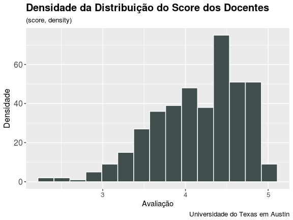

```r
evals0_150 %>%
  ggplot(aes(x = score)) +
  geom_histogram(bins = 15, fill = paleta[1], colour = 'white') +
    labs(x='Avaliação',
        y="Densidade",
        title="Densidade da Distribuição do Score dos Docentes",
        subtitle="(score, density)",
        caption="Universidade do Texas em Austin") +
    theme(plot.title = element_text(face="bold",size = "15"),
        plot.subtitle = element_text(size = "10"),
        plot.caption = element_text(size="10"),
        axis.title.y = element_text(size="12"),
        axis.text.x = element_text(size="10"),
        axis.text.y = element_text(size="12"),
        legend.position="none",
        panel.border=element_blank())
```

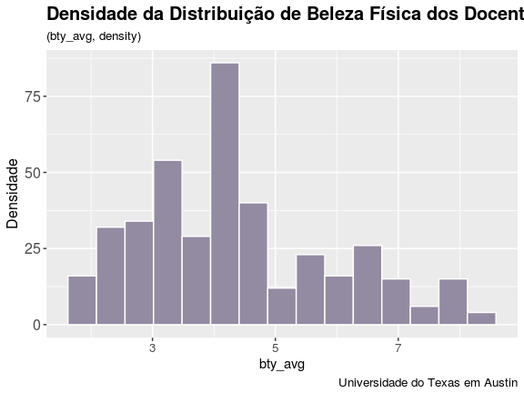

```r
evals0_150 %>%
  ggplot(aes(x = bty_avg)) +
  geom_histogram(bins = 15, fill = paleta[3], colour = 'white') +
    labs(x='bty_avg',
        y="Densidade",
        title="Densidade da Distribuição de Beleza Física dos Docentes",
        subtitle="(bty_avg, density)",
        caption="Universidade do Texas em Austin") +
    theme(plot.title = element_text(face="bold",size = "15"),
        plot.subtitle = element_text(size = "10"),
        plot.caption = element_text(size="10"),
        axis.title.y = element_text(size="12"),
        axis.text.x = element_text(size="10"),
        axis.text.y = element_text(size="12"),
        legend.position="none",
        panel.border=element_blank())
```

Abaixo podemos ver que a correlação entre beleza e avaliação do professor parece bem tênue.

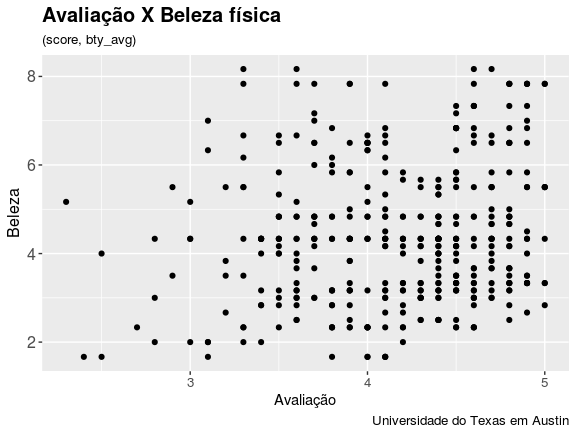

```r
evals0_150 %>%
  ggplot(aes(x = score, y = bty_avg)) +
  geom_point() +
    labs(x='Avaliação',
        y="Beleza",
        title="Avaliação X Beleza física",
        subtitle="(score, bty_avg)",
        caption="Universidade do Texas em Austin") +
    theme(plot.title = element_text(face="bold",size = "15"),
        plot.subtitle = element_text(size = "10"),
        plot.caption = element_text(size="10"),
        axis.title.y = element_text(size="12"),
        axis.text.x = element_text(size="10"),
        axis.text.y = element_text(size="12"),
        legend.position="none",
        panel.border=element_blank())
```

Agora observe a distribuição das outras quatro variáveis (conjunto **X** da etapa 2) e sua correlação com a avaliação do professor.

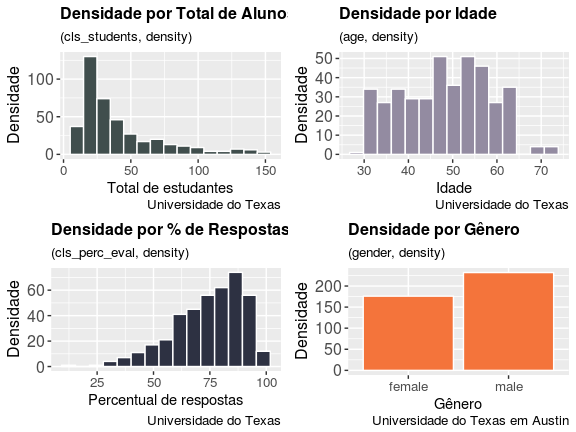

```r
d1<-evals0_150 %>%
  ggplot(aes(x = cls_students)) +
  geom_histogram(bins = 15,fill = paleta[1], colour = 'white') +
    labs(x='Total de estudantes',
        y="Densidade",
        title="Densidade por Total de Alunos",
        subtitle="(cls_students, density)",
        caption="Universidade do Texas") +
    theme(plot.title = element_text(face="bold",size = "12"),
        plot.subtitle = element_text(size = "10"),
        plot.caption = element_text(size="10"),
        axis.title.y = element_text(size="12"),
        axis.text.x = element_text(size="10"),
        axis.text.y = element_text(size="12"),
        legend.position="none",
        panel.border=element_blank())

d2<-evals0_150 %>%
  ggplot(aes(x = age)) +
  geom_histogram(bins = 15, fill = paleta[3], colour = 'white') +
    labs(x='Idade',
        y="Densidade",
        title="Densidade por Idade",
        subtitle="(age, density)",
        caption="Universidade do Texas") +
    theme(plot.title = element_text(face="bold",size = "12"),
        plot.subtitle = element_text(size = "10"),
        plot.caption = element_text(size="10"),
        axis.title.y = element_text(size="12"),
        axis.text.x = element_text(size="10"),
        axis.text.y = element_text(size="12"),
        legend.position="none",
        panel.border=element_blank())

d3<-evals0_150 %>%
  ggplot(aes(x = cls_perc_eval)) +
  geom_histogram(bins = 15, fill = paleta[4], colour = 'white') +
    labs(x='Percentual de respostas',
        y="Densidade",
        title="Densidade por % de Respostas",
        subtitle="(cls_perc_eval, density)",
        caption="Universidade do Texas") +
    theme(plot.title = element_text(face="bold",size = "12"),
        plot.subtitle = element_text(size = "10"),
        plot.caption = element_text(size="10"),
        axis.title.y = element_text(size="12"),
        axis.text.x = element_text(size="10"),
        axis.text.y = element_text(size="12"),
        legend.position="none",
        panel.border=element_blank())

d4<-evals0_150 %>%
  ggplot(aes(x = gender)) +
  geom_bar(fill = paleta[5], colour = 'white') +
    labs(x='Gênero',
        y="Densidade",
        title="Densidade por Gênero",
        subtitle="(gender, density)",
        caption="Universidade do Texas em Austin") +
    theme(plot.title = element_text(face="bold",size = "12"),
        plot.subtitle = element_text(size = "10"),
        plot.caption = element_text(size="10"),
        axis.title.y = element_text(size="12"),
        axis.text.x = element_text(size="10"),
        axis.text.y = element_text(size="12"),
        legend.position="none",
        panel.border=element_blank())

grid.arrange(arrangeGrob(d1,d2,ncol=2,widths=c(1,1)),
    arrangeGrob(d3,d4,ncol=2,widths=c(1,1)),
    heights=c(1,1))
```

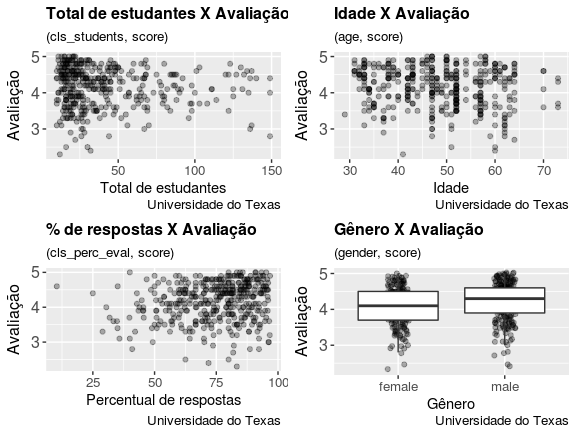

```r
p1<-evals0_150 %>%
  ggplot(aes(y = score, x = cls_students)) +
  geom_point(alpha = .3) +
    labs(y='Avaliação',
        x="Total de estudantes",
        title="Total de estudantes X Avaliação",
        subtitle="(cls_students, score)", caption="Universidade do Texas"
        ) +
    theme(plot.title = element_text(face="bold",size = "12"),
        plot.subtitle = element_text(size = "10"),
        plot.caption = element_text(size="10"),
        axis.title.y = element_text(size="12"),
        axis.text.x = element_text(size="10"),
        axis.text.y = element_text(size="12"),
        legend.position="none",
        panel.border=element_blank())

p2<-evals0_150 %>%
  ggplot(aes(y = score, x = age)) +
  geom_point(alpha = .3) +
    labs(y='Avaliação',
        x="Idade",
        title="Idade X Avaliação",
        subtitle="(age, score)", caption="Universidade do Texas"
        ) +
    theme(plot.title = element_text(face="bold",size = "12"),
        plot.subtitle = element_text(size = "10"),
        plot.caption = element_text(size="10"),
        axis.title.y = element_text(size="12"),
        axis.text.x = element_text(size="10"),
        axis.text.y = element_text(size="12"),
        legend.position="none",
        panel.border=element_blank())


p3<-evals0_150 %>%
  ggplot(aes(y = score, x = cls_perc_eval)) +
  geom_point(alpha = .3) +
    labs(y='Avaliação',
        x="Percentual de respostas",
        title="% de respostas X Avaliação",
        subtitle="(cls_perc_eval, score)", caption="Universidade do Texas"
        ) +
    theme(plot.title = element_text(face="bold",size = "12"),
        plot.subtitle = element_text(size = "10"),
        plot.caption = element_text(size="10"),
        axis.title.y = element_text(size="12"),
        axis.text.x = element_text(size="10"),
        axis.text.y = element_text(size="12"),
        legend.position="none",
        panel.border=element_blank())


p4<-evals0_150 %>%
  ggplot(aes(y = score, x = gender)) +
  geom_jitter(width = .1, alpha = .3) +
  geom_boxplot(outlier.alpha = .0) +
    labs(y='Avaliação',
        x="Gênero",
        title="Gênero X Avaliação",
        subtitle="(gender, score)", caption="Universidade do Texas"
        ) +
    theme(plot.title = element_text(face="bold",size = "12"),
        plot.subtitle = element_text(size = "10"),
        plot.caption = element_text(size="10"),
        axis.title.y = element_text(size="12"),
        axis.text.x = element_text(size="10"),
        axis.text.y = element_text(size="12"),
        legend.position="none",
        panel.border=element_blank())

grid.arrange(arrangeGrob(p1,p2,ncol=2,widths=c(1,1)),
    arrangeGrob(p3,p4,ncol=2,widths=c(1,1)),
    heights=c(1,1))
```

Perceba que separadamente não fica clara uma correlação de cada fator do conjunto **X** com a avaliação do professor. Buscarei detalhes deste relacionamento com base nas técnicas de regressão estudadas.

# A análise

### 1. Vou começar com uma regressão linear simples para medir a correlação entre `score` (avaliação em si) e `bty_avg` (avaliação da aparência do professor).

A pergunta a ser respondida aqui é: Qual a correlação entre a aparência física do professor e sua avaliação pelos alunos. Lembrando que dividimos nossa base em cursos com mais de 150 alunos e cursos com menos de 150 alunos.

```r
modelo1 = lm(score ~ bty_avg, data = evals0_150)

modelo1b = lm(score ~ bty_avg, data = evals151_)
```

```r
tidy(modelo1, conf.int = TRUE, conf.level = 0.95)
```

```
##          term   estimate  std.error statistic       p.value   conf.low
## 1 (Intercept) 3.93258871 0.08072505 48.715843 1.110523e-171 3.77389746
## 2     bty_avg 0.05178203 0.01731104  2.991272  2.947534e-03 0.01775157
##   conf.high
## 1 4.0912800
## 2 0.0858125
```

```r
glance(modelo1)
```

```
##    r.squared adj.r.squared     sigma statistic     p.value df    logLik
## 1 0.02156346    0.01915352 0.5426667   8.94771 0.002947534  2 -328.5304
##        AIC      BIC deviance df.residual
## 1 663.0608 675.0946 119.5618         406
```

```r
tidy(modelo1b, conf.int = TRUE, conf.level = 0.95)
```

```
##          term  estimate std.error statistic      p.value  conf.low
## 1 (Intercept) 2.4321930 0.2932504  8.293912 3.830194e-09 1.8324286
## 2     bty_avg 0.3742329 0.0608892  6.146129 1.067544e-06 0.2497005
##   conf.high
## 1 3.0319574
## 2 0.4987653
```

```r
glance(modelo1b)
```

```
##   r.squared adj.r.squared     sigma statistic      p.value df    logLik
## 1 0.5657051     0.5507294 0.3963216  37.77491 1.067544e-06  2 -14.26197
##        AIC     BIC deviance df.residual
## 1 34.52394 38.8259 4.555053          29
```

Para visualizar os modelos:

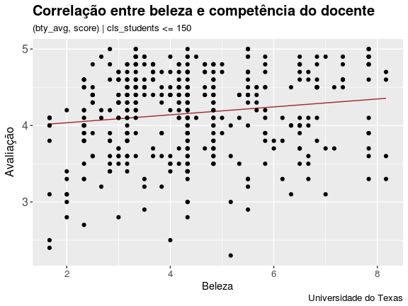

```r
evals_augmented = evals0_150 %>%
  add_predictions(modelo1)

evals_augmented %>%
  ggplot(aes(x = bty_avg)) +
  geom_line(aes(y = pred), colour = "brown") +
  geom_point(aes(y = score))+
    labs(x='Beleza',
        y="Avaliação",
        title="Correlação entre beleza e competência do docente",
        subtitle="(bty_avg, score) | cls_students <= 150",
        caption="Universidade do Texas") +
    theme(plot.title = element_text(face="bold",size = "15"),
        plot.subtitle = element_text(size = "10"),
        plot.caption = element_text(size="10"),
        axis.title.y = element_text(size="12"),
        axis.text.x = element_text(size="10"),
        axis.text.y = element_text(size="12"),
        legend.position="none",
        panel.border=element_blank())
```

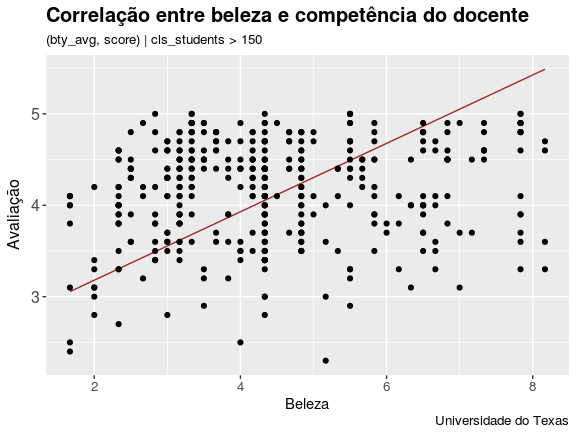

```r
evals_augmented = evals0_150 %>%
  add_predictions(modelo1b)

evals_augmented %>%
  ggplot(aes(x = bty_avg)) +
  geom_line(aes(y = pred), colour = "brown") +
  geom_point(aes(y = score))+
    labs(x='Beleza',
        y="Avaliação",
        title="Correlação entre beleza e competência do docente",
        subtitle="(bty_avg, score) | cls_students > 150",
        caption="Universidade do Texas") +
    theme(plot.title = element_text(face="bold",size = "15"),
        plot.subtitle = element_text(size = "10"),
        plot.caption = element_text(size="10"),
        axis.title.y = element_text(size="12"),
        axis.text.x = element_text(size="10"),
        axis.text.y = element_text(size="12"),
        legend.position="none",
        panel.border=element_blank())
```

Se considerarmos que temos apenas uma amostra de nosso universo de avaliações discentes de fim de período, o que podemos inferir a partir desse modelo sobre a relação entre a aparência física do professor e sua avaliação pelo aluno?

O que podemos concluir sobre a correlação entre estas duas variáveis nas duas amostras que separamos (e não população, com certa confiança)?

> Com base no que foi observado é possível tirar duas conclusões, cada uma relacionada a sua amostra. Na amostra de cursos com até 150 alunos, apesar da alta significância dos resultados, a magnitude da correlação foi muito baixa, o que pode significar um nível mais elevado de comprometimento dos alunos para com a avaliação. Já na amostra de cursos com mais de 150 alunos, também com alta significância, percebemos que a magnitude da influência da beleza física na avaliação dos alunos é muito elevada levando o domínio de `score` [0,00;5,00], o que pode ser um sinal de falta de comprometimento. Com base nos resultados, temos boas evidências que argumentam a favor de um nível de comprometimento (com a avaliação) mais elevado dos estudantes em cursos com menos alunos.

### 2. Aqui faremos algo mais elaborado. A ideia é propor um modelo que explique o comportamento de `score` não apenas usando `bty_avg` (beleza), mas também outros fatores relacionados à aparência física do professor ou algum fator que possa influenciar as avaliações. Proponho medir a correlação entre `score` ~ `bty_avg` + X, sendo X = {`age`,`gender`,`cls_perc_eval`,`cls_students`}.

Da analise anterior trazemos uma boa noção de como a beleza do professor influencia sua avaliação em cursos com mais e menos alunos. Agora podemos testar mais variáveis criando um modelo de regressão linear múltipla que descreva melhor estas relações.

`age` e `gender` são variáveis que, de modo mais óbvio, estão relacionados a beleza física do professor na votação por parte dos alunos. Espero que `age` colabore de forma crescente com o `score` do professor, já `gender`, uma variável categórica, também deve ter relevância significativa. Finalmente, `cls_perc_eval` e `cls_students`, que tratam de questões mais relacionadas a motivos para falta de atenção, representam uma hipótese mais difícil de interpretar, mas creio que tenham fatores crescentes. Uma associação entre estas variáveis e `bty_avg` para descrever `score` seria um modelo melhor que o da análise anterior?

Particularmente, começarei fazendo quatro regressões múltiplas separadas, cada uma envolvendo `bty_avg` e um elemento de **X**, e observo a correlação existente com `score` em cada um dos quatro modelos apenas no contexto da amostra de até 150 alunos. Em seguida observo o comportamento das correlações em um novo modelo multivariado, agora envolvendo todas as quatro variáveis e `bty_avg`. O modelo final é aplicado às duas amostras (<=150 e >150), comparando os resultados. A pergunta que quero responder aqui é: **Estes quatro fatores têm mais influência em `score` que `bty_avg` isoladamente?**

```r
modelo2 = lm(score ~ bty_avg + cls_students, data = evals0_150 )
modelo3 = lm(score ~ bty_avg + age, data = evals0_150)
modelo4 = lm(score ~ bty_avg + cls_perc_eval, data = evals0_150)
modelo5 = lm(score ~ bty_avg + gender, data = evals0_150)
```

```r
tidy(modelo2, conf.int = TRUE, conf.level = 0.95)
```

```
##           term     estimate    std.error statistic       p.value
## 1  (Intercept)  3.987160982 0.0873073815 45.668086 7.857349e-162
## 2      bty_avg  0.052274390 0.0172790485  3.025305  2.642167e-03
## 3 cls_students -0.001400075 0.0008632252 -1.621911  1.056005e-01
##       conf.low    conf.high
## 1  3.815528753 4.1587932100
## 2  0.018306567 0.0862422117
## 3 -0.003097036 0.0002968867
```

```r
glance(modelo2)
```

```
##    r.squared adj.r.squared     sigma statistic     p.value df    logLik
## 1 0.02787769    0.02307709 0.5415802  5.807121 0.003262003  3 -327.2096
##        AIC      BIC deviance df.residual
## 1 662.4193 678.4643 118.7902         405
```

```r
tidy(modelo3, conf.int = TRUE, conf.level = 0.95)
```

```
##          term     estimate   std.error statistic      p.value    conf.low
## 1 (Intercept)  4.252252650 0.184241703 23.079751 7.744340e-76  3.89006318
## 2     bty_avg  0.039987421 0.018305129  2.184493 2.949879e-02  0.00400249
## 3         age -0.005543751 0.002874444 -1.928634 5.447489e-02 -0.01119445
##      conf.high
## 1 4.6144421194
## 2 0.0759723520
## 3 0.0001069428
```

```r
glance(modelo3)
```

```
##    r.squared adj.r.squared     sigma statistic     p.value df    logLik
## 1 0.03046791    0.02568009 0.5408582  6.363638 0.001900393  3 -326.6654
##        AIC      BIC deviance df.residual
## 1 661.3307 677.3758 118.4737         405
```

```r
tidy(modelo4, conf.int = TRUE, conf.level = 0.95)
```

```
##            term    estimate   std.error statistic      p.value    conf.low
## 1   (Intercept) 3.585114220 0.141633764 25.312568 1.910534e-85 3.306685088
## 2       bty_avg 0.042154920 0.017449642  2.415804 1.614218e-02 0.007851738
## 3 cls_perc_eval 0.005232675 0.001760503  2.972262 3.132565e-03 0.001771811
##    conf.high
## 1 3.86354335
## 2 0.07645810
## 3 0.00869354
```

```r
glance(modelo4)
```

```
##    r.squared adj.r.squared     sigma statistic      p.value df    logLik
## 1 0.04245066    0.03772203 0.5375055  8.977354 0.0001531563  3 -324.1283
##        AIC      BIC deviance df.residual
## 1 656.2567 672.3018 117.0094         405
```

```r
tidy(modelo5, conf.int = TRUE, conf.level = 0.95)
```

```
##          term   estimate  std.error statistic       p.value   conf.low
## 1 (Intercept) 3.80770966 0.09017802 42.224367 1.978548e-150 3.63043422
## 2     bty_avg 0.05917401 0.01732081  3.416353  6.988533e-04 0.02512409
## 3  gendermale 0.16245031 0.05427602  2.993040  2.931306e-03 0.05575242
##    conf.high
## 1 3.98498509
## 2 0.09322393
## 3 0.26914821
```

```r
glance(modelo5)
```

```
##    r.squared adj.r.squared    sigma statistic      p.value df    logLik
## 1 0.04273738    0.03801016 0.537425  9.040695 0.0001441444  3 -324.0673
##        AIC      BIC deviance df.residual
## 1 656.1345 672.1796 116.9744         405
```

Visualizar o modelo com muitas variáveis independentes fica mais difícil. Novamente testamos a correlação de certas variáveis com uma variável resposta `score` (o código acima). Aqui utilizamos sucessivas regressões lineares múltiplas para testar a correlação entre a variável resposta, `bty_avs` e as quatro variáveis de **X**.

A princípio medimos a correlação entre `score`, `bty_avg` e cada variável de **X** separadamente na amostra de cursos com 150 alunos ou menos. Nosso intuito é estimar os R2 e comparar cada um deles com um modelo envolvendo todas as variáveis e assim, confirmar o pressuposto de não linearidade entre os dados. Com isto, assim que testarmos o modelo completo, caso este seja melhor que os modelos atuais, teremos uma evidência de que não há fatores exercendo influências cruzadas em pares.

```r
para_plotar_modelo2 = evals0_150 %>%
  data_grid(
            bty_avg = seq_range(bty_avg, 9),
            cls_students = seq_range(cls_students,3)) %>%
  add_predictions(modelo2)

para_plotar_modelo3 = evals0_150 %>%
  data_grid(
            bty_avg = seq_range(bty_avg, 9),
            age = seq_range(age, 3)) %>%
  add_predictions(modelo3)

para_plotar_modelo4 = evals0_150 %>%
  data_grid(
            bty_avg = seq_range(bty_avg, 9),
            cls_perc_eval = seq_range(cls_perc_eval, 3)) %>%
  add_predictions(modelo4)

para_plotar_modelo5 = evals0_150 %>%
  add_predictions(modelo5)
```

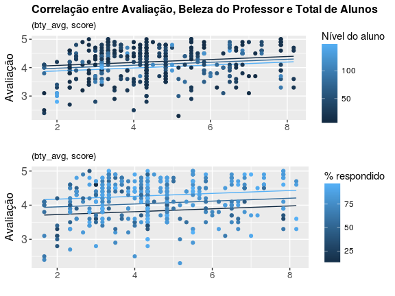

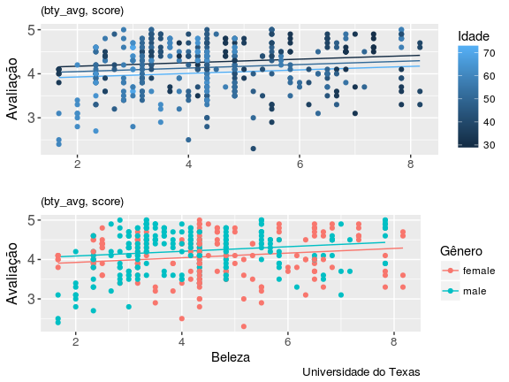

```r
p1<-para_plotar_modelo2 %>%
  ggplot(aes(x = bty_avg, y = pred)) +
  geom_line(aes(group = cls_students, colour = cls_students)) +
  geom_point(data = evals0_150, aes(y = score, colour = cls_students))+
    labs(x=" ",
        y="Avaliação",
        title="Correlação entre Avaliação, Beleza do Professor e Total de Alunos",
        subtitle="(bty_avg, score)",
        colour="Nível do aluno",
        caption=NULL) +
    theme(plot.title = element_text(face="bold",size = "12"),
        plot.subtitle = element_text(size = "10"),
        #plot.caption = element_text(size="10"),
        axis.title.y = element_text(size="12"),
        axis.text.x = element_text(size="10"),
        axis.text.y = element_text(size="12"),
        legend.position="right",
        panel.border=element_blank())

p2<-para_plotar_modelo3 %>%
  ggplot(aes(x = bty_avg, y = pred)) +
  geom_line(aes(group = age, colour = age)) +
  geom_point(data = evals0_150, aes(y = score, colour = age))+
    labs(x=" ",
        y="Avaliação",
        title=NULL,
        subtitle="(bty_avg, score)",
        colour="Idade",
        caption=NULL) +
    theme(plot.title = element_text(face="bold",size = "12"),
        plot.subtitle = element_text(size = "10"),
        #plot.caption = element_text(size="10"),
        axis.title.y = element_text(size="12"),
        axis.text.x = element_text(size="10"),
        axis.text.y = element_text(size="12"),
        legend.position="right",
        panel.border=element_blank())

p3<-para_plotar_modelo4 %>%
  ggplot(aes(x = bty_avg, y = pred)) +
  geom_line(aes(group = cls_perc_eval, colour = cls_perc_eval)) +
  geom_point(data = evals0_150, aes(y = score, colour = cls_perc_eval))+
    labs(x=' ',
        y="Avaliação",
        title=NULL,
        subtitle="(bty_avg, score)",
        colour="% respondido",
        caption=NULL) +
    theme(#plot.title = element_text(face="bold",size = "12"),
        plot.subtitle = element_text(size = "10"),
        #plot.caption = element_text(size="10"),
        axis.title.y = element_text(size="12"),
        axis.text.x = element_text(size="10"),
        axis.text.y = element_text(size="12"),
        legend.position="right",
        panel.border=element_blank())

p4<-para_plotar_modelo5 %>%
  ggplot(aes(x = bty_avg, y = pred)) +
  geom_line(aes(group = gender, colour = gender)) +
  geom_point(data = evals0_150, aes(y = score, colour = gender))+
    labs(x='Beleza',
        y="Avaliação",
        title=NULL,
        subtitle="(bty_avg, score)",
        colour="Gênero",
        caption="Universidade do Texas") +
    theme(#plot.title = element_text(face="bold",size = "12"),
        plot.subtitle = element_text(size = "10"),
        plot.caption = element_text(size="10"),
        axis.title.y = element_text(size="12"),
        axis.text.x = element_text(size="10"),
        axis.text.y = element_text(size="12"),
        legend.position="right",
        panel.border=element_blank())
```

Agora o modelo completo: `score` ~ `bty_avg` + `cls_students` + `age` + `cls_perc_eval` + `gender`

```r
modelo6 = lm(score ~ bty_avg + cls_students + age + cls_perc_eval + gender, data = evals0_150)

modelo6b = lm(score ~ bty_avg + cls_students + age + cls_perc_eval + gender, data = evals151_)
```

```r
tidy(modelo6, conf.int = TRUE, conf.level = 0.95)
```

```
##            term     estimate   std.error statistic      p.value
## 1   (Intercept)  4.024778765 0.244768052 16.443236 7.846171e-47
## 2       bty_avg  0.036455971 0.018124651  2.011403 4.494989e-02
## 3  cls_students -0.001085339 0.000902384 -1.202746 2.297825e-01
## 4           age -0.008141808 0.002959853 -2.750747 6.214677e-03
## 5 cls_perc_eval  0.004024308 0.001842285  2.184412 2.950905e-02
## 6    gendermale  0.198191891 0.055192319  3.590932 3.702663e-04
##        conf.low     conf.high
## 1  3.5435934952  4.5059640352
## 2  0.0008250345  0.0720869071
## 3 -0.0028593197  0.0006886423
## 4 -0.0139605324 -0.0023230843
## 5  0.0004025931  0.0076460237
## 6  0.0896902686  0.3066935136
```

```r
glance(modelo6)
```

```
##    r.squared adj.r.squared     sigma statistic      p.value df    logLik
## 1 0.08143202    0.07000704 0.5284118  7.127545 2.101856e-06  6 -315.6498
##        AIC      BIC deviance df.residual
## 1 645.2997 673.3785  112.246         402
```

```r
tidy(modelo6b, conf.int = TRUE, conf.level = 0.95)
```

```
##            term      estimate    std.error  statistic      p.value
## 1   (Intercept)  1.4146768129 0.3617017178  3.9111697 0.0006221942
## 2       bty_avg  0.3123484066 0.0602820057  5.1814535 0.0000233216
## 3  cls_students -0.0005404826 0.0005265068 -1.0265444 0.3144656636
## 4           age  0.0008817201 0.0061007076  0.1445275 0.8862427548
## 5 cls_perc_eval  0.0129283568 0.0063443798  2.0377653 0.0522875654
## 6    gendermale  0.8561560621 0.1867274681  4.5850569 0.0001092390
##       conf.low    conf.high
## 1  0.669738181 2.1596154453
## 2  0.188195292 0.4365015215
## 3 -0.001624844 0.0005438785
## 4 -0.011682922 0.0134463625
## 5 -0.000138138 0.0259948516
## 6  0.471583643 1.2407284815
```

```r
glance(modelo6b)
```

```
##   r.squared adj.r.squared     sigma statistic      p.value df    logLik
## 1 0.7990622     0.7588747 0.2903455  19.88333 5.468253e-08  6 -2.315677
##        AIC      BIC deviance df.residual
## 1 18.63135 28.66926 2.107513          25
```

Para o modelo final, convertendo nossas variáveis em uma descrição textual: Queremos saber se a aparência física do professor aliada à sua idade e sexo exercem influência sobre a avaliação que os alunos fazem dele, além de descobrir se o tamanho da turma e a taxa de resposta à avaliação também se correlacionam com sua pontuação.

Utilizando regressão linear múltipla, analisamos se há correlação significativa entre `score` e `bty_avg`, `age`, `gender`, `cls_perc_eval` e `cls_students` em ambas as amostras. Os resultados mostraram que mesmo o modelo com cinco preditores no formato `score` = B0 + Bn.X, sendo n=|X| explica apenas 8,14% (pouco, porém, melhor que qualquer um dos modelos anteriores com apenas um ou dois preditores) do comportamento da variável de resposta `score` na amostra de cursos com 150 alunos ou menos (R2=0.0814). Já para a amostra de cursos com mais de 150 alunos, este modelo descreve muito bem a variável resposta à quase 80% (R2=0,799).

[output not shown]

[output not shown]

# Sumário

A partir dos modelos propostos identificamos que o gênero e a beleza do professor de fato exercem influência sobre a avaliação do aluno. Contudo, tal influência tem magnitude muito baixa em cursos com 150 alunos ou menos e muito alta em cursos de ensino em massa com mais de 150 alunos (descreve 80% do comportamento da amostra). Além disto, foi surpreendente constatar que, diferente do esperado, a idade do professor é pouco significativa para o modelo, mesmo em cursos voltados para ensino em larga escala, onde vimos que o fator beleza é significativo e muito relevante.

Uma próxima medida seria definir o que leva alunos do ensino em massa a apresentar tal comportamento em avaliações.